# Lab1

Arden Chaing

Phys 434 AA

October 10th 2020

Lab #1

```python
# necessary imports for this lab
%matplotlib inline
import numpy as np
import matplotlib
import matplotlib.pyplot as plt
import scipy
from scipy import stats
from scipy.stats import binom

plt.rcParams["figure.figsize"] = (15,10)
```

Part 1: A Little Statistics

```python
# 1.1.B
print("Sigma = 0 | Probablity = " + str(stats.norm.cdf(0)))
print("Sigma = 1 | Probablity = " + str(stats.norm.cdf(1)))
print("Sigma = 2 | Probablity = " + str(stats.norm.cdf(2)))
print("Sigma = 3 | Probablity = " + str(stats.norm.cdf(3)))
```

```
Sigma = 0 | Probablity = 0.5
Sigma = 1 | Probablity = 0.8413447460685429
Sigma = 2 | Probablity = 0.9772498680518208
Sigma = 3 | Probablity = 0.9986501019683699
```

Problem 1.1.B: Above we are calculating the probablity that a value is between the left end bound (negative infinity) and the associated z value in a standard normal distribution. We are doing so utilizing the cumulative distrbution function (CDF). Looking at a typical bell curve graph we can see that the data spread is split equally between the mean. That is further confirmed with the first value which asks what is the probablity that a value is between negative infinity and the mean plus zero standard deviation (which is just the mean). It's 50%. Also we can further validate this claim since we know that within one standard deviation of the mean, it encapsulates 68% of the data. And within two standard deviations of the mean, it encapsulates 95% of the data. Using this knowledge we can say that the probablity that a value is between negative infinity and two standard deviations above the mean is (1/2)(.95) + (.50) = 97.5% which is pretty close to the value we calculated above which was 97.72%.

```python
# 1.1.C
print("Probablity = 0.5 | Sigma = " + str(stats.norm.ppf(0.5)))
print("Probablity = 0.84134 | Sigma = " + str(stats.norm.ppf(0.84134)))
print("Probablity = 0.97725 | Sigma = " + str(stats.norm.ppf(0.97725)))
print("Probablity = 0.99865 | Sigma = " + str(stats.norm.ppf(0.99865)))
```

```
Probablity = 0.5 | Sigma = 0.0
Probablity = 0.84134 | Sigma = 0.9999803859660787
Probablity = 0.97725 | Sigma = 2.0000024438996027
Probablity = 0.99865 | Sigma = 2.9999769927034015
```

Problem 1.1C: Above I wanted to verify what is the probablity associated with a z table value utlizing the percent point function (PPF). Using the associated z table probablities from the sigmas I chose in 1b, I performed the inverse operation of the CDF in order to confirm that the sigma values matched the probablities of a normal distrubution. And we can confirm that with a probabablity of 99.8% it will yield a z value close to +3 because we know that a within three standard deviations of the mean, the probablity is 99.75%. Thus 50 + (1/2)(99.75) = 99.875%.

```python
# 1.1.D
print("Sigma = 3 | Probablity = " + str(stats.norm.cdf(3)))
print("Sigma = 2 | Probablity = " + str(stats.norm.cdf(2)))
print("Sigma = 1 | Probablity = " + str(stats.norm.cdf(1)))
print("Sigma = 0 | Probablity = " + str(stats.norm.cdf(0)))
print("Sigma = -1 | Probablity = " + str(stats.norm.cdf(-1)))
print("Sigma = -2 | Probablity = " + str(stats.norm.cdf(-2)))
print("Sigma = -3 | Probablity = " + str(stats.norm.cdf(-3)))
```

```
Sigma = 3 | Probablity = 0.9986501019683699
Sigma = 2 | Probablity = 0.9772498680518208
Sigma = 1 | Probablity = 0.8413447460685429
Sigma = 0 | Probablity = 0.5
Sigma = -1 | Probablity = 0.15865525393145707
Sigma = -2 | Probablity = 0.022750131948179195
Sigma = -3 | Probablity = 0.0013498980316300933
```

Problem 1.1.D: One cannot have a negative probablity as it ranges from 0 to 1 (or 0% to 100%). However, you can have a negative z value. It's the same process as 1b, where you look at the probablity of finding the value between negative infinity and the z value. But because the z value is negative, the ending point of integration will be before the mean. Using the same values as 1b you can see that it follows the normal distrubution probablity breakdown. Example being that the probability of finding a value between negative infinity and one standard deviation before the mean is 50 - (1/2)(68) = 16%.

In addition, a normal distrubution's probablity of +/- z values will always equal 1. This is displayed below.

```python
print("Sum of +/- 1 sigma is " + str(stats.norm.cdf(-1) + stats.norm.cdf(1)))
print("Sum of +/- 2 sigma is " + str(stats.norm.cdf(-2) + stats.norm.cdf(2)))
print("Sum of +/- 3 sigma is " + str(stats.norm.cdf(-3) + stats.norm.cdf(3)))
```

```
Sum of +/- 1 sigma is 1.0
Sum of +/- 2 sigma is 1.0
Sum of +/- 3 sigma is 1.0
```

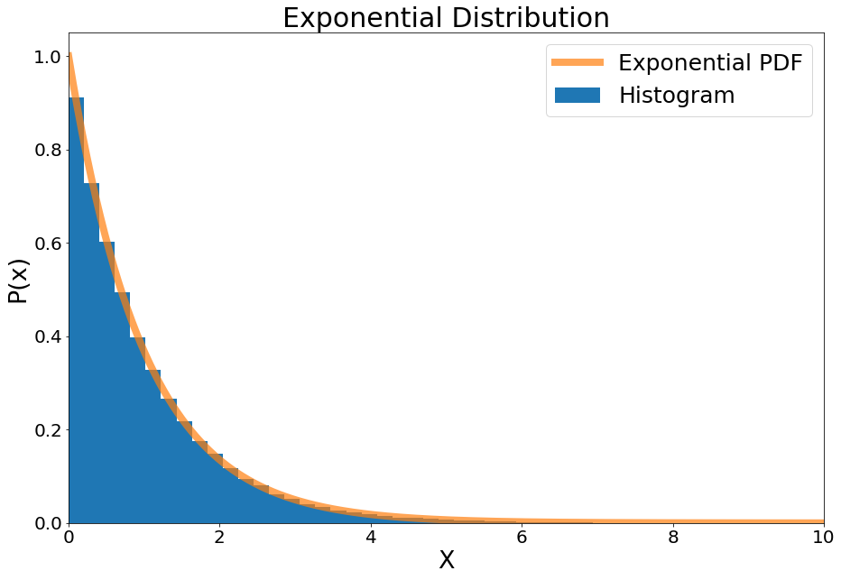

```python
# 1.2.A-B
d = stats.expon.rvs(loc = 0, scale = 1, size = 100000)
fig, ax = plt.subplots(1, 1)
ax.hist(d,50, density=True, label='Histogram')
plt.tick_params(labelsize = 20)
plt.xlim([0,10])
x = np.linspace(0,10,500)
ax.plot(x,stats.expon.pdf(x,loc = 0, scale = 1), linewidth = 8,alpha = 0.7, label = 'Exponential PDF')
plt.xlabel('X', fontsize = 27)
plt.ylabel('P(x)', fontsize = 27)
plt.title('Exponential Distribution', fontsize = 30)
plt.legend(fontsize=25)
plt.show()
```

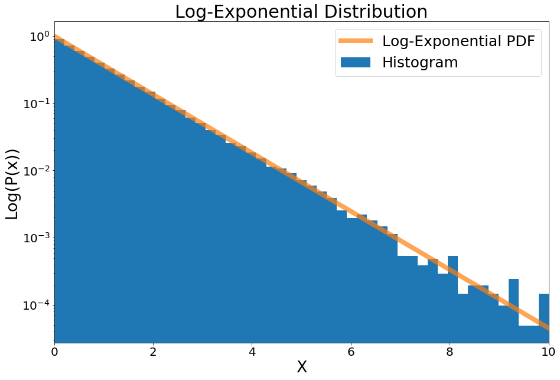

```python
fig, ax = plt.subplots(1, 1)
ax.hist(d,50, density=True, label='Histogram')
plt.yscale('log')
plt.tick_params(labelsize = 20)
plt.xlim([0,10])
x = np.linspace(0,10,500)
ax.plot(x,stats.expon.pdf(x,loc = 0, scale = 1),linewidth = 8,alpha = 0.7, label='Log-Exponential PDF')
plt.xlabel('X', fontsize = 27)
plt.ylabel('Log(P(x))', fontsize = 27)
plt.title('Log-Exponential Distribution', fontsize = 30)
plt.legend(fontsize=25)
plt.show()
```

Problem 1.2.A: An exponential distribution is a continuous "probablity distribution of the time between events in a Poisson point process" - which is when events happen independently and continously at an average constant rate. The probablity density function is f(x) = lambda*e^(-lambda* x) where lambda is considered the rate and must be larger than zero. https://en.wikipedia.org/wiki/Exponential_distribution

Problem 1.2.B: Both graphs are showcasing the exponential probablity distribution with 500 samples spaced evenly between zero and ten. In the blue is a 100k randomly generated points that mimics the exponential curve. When plotting the exponential distrbution, I chose lambda to be equal to one. Thus the PDF = e^(-x). This function also has several properties such as the expected value = 1/lambda and the varience = 1/(lambda)^2 = mean. Therefore the mean of our data is 1/1 = 1. Also the median is given by ln(2)/lambda < E[X]. That means that from zero to ln(2)/1 = .693, contains 50% of the values of the exponential distrubution.

However, the there's a difference between the top and bottom graph in that the bottom one is a log scale graph. Changing the y axis into a logarithmic scale allows the viewer to visualize a large range of values in a very compact way - giving a better insight on the pattern of the data and also allowing a visual verification of the exponential law of the function.

Problem 1.3.A: I'm choosing x = 1 as my value.

Problem 1.3.B: For a standard exponential distrbution with lambda equal to one, what is the probablity that I measure a value between one and the median?

Problem 1.3.C: We should take the area under the furve of the PDF from the median value to one. Thefore the integral is from ln(2) to one of e^(-x).

```python
# 1.3.D
print ("What is the median value? " + str(stats.expon.ppf(.5)))
print ("What is the probablity between neg inf and 1? " + str(stats.expon.cdf(1)))
print ("What is the probabltiy between " + str(stats.expon.ppf(.5)) + " and 1? " + str(stats.expon.cdf(1) - .5))
```

```
What is the median value? 0.6931471805599453
What is the probablity between neg inf and 1? 0.6321205588285577
What is the probabltiy between 0.6931471805599453 and 1? 0.13212055882855767
```

Problem 1.3.D: The probablity of finding a value between the median and one is 13.2%. This was discovered by finding the difference between the probablity between (neg inf to one) and (neg inf to the median) since it would yield area between (the median and one). We utilized the CDF operation in order to find the first probablity and we knew the second probablity (since it was the median half the values were below and half were above).

```python
# 1.3.E
print ("Probablity between neg inf to one is " + str(stats.expon.cdf(1)))
print ("The sigma associated is " + str(stats.expon.ppf(stats.expon.cdf(1))-1))
```

```
Probablity between neg inf to one is 0.6321205588285577
The sigma associated is 0.0
```

Problem 1.3.E: A special property of an exponential distrubution is that the mean is equal to the standard deviation. The mean is also 1/lambda, which is equal to 1. It just so happens that the value one is exactly the mean, thus the sigma value associated is 0 which is confirmed above.

```python
print("x = .1 | Sigma = " + str("{0:.2f}").format(stats.expon.ppf(stats.expon.cdf(.1))-1) + " | Probablity from neg inf to x = " + str("{0:.3f}".format(stats.expon.cdf(.1))))
print("x = .5 | Sigma = " + str("{0:.2f}").format(stats.expon.ppf(stats.expon.cdf(.5))-1) + " | Probablity from neg inf to x = " + str("{0:.3f}".format(stats.expon.cdf(.5))))
print("x = 1.5 | Sigma = " + str("{0:.2f}").format(stats.expon.ppf(stats.expon.cdf(1.5))-1) + " | Probablity from neg inf to x = " + str("{0:.3f}".format(stats.expon.cdf(1.5))))
print("x = 2 | Sigma = " + str("{0:.2f}").format(stats.expon.ppf(stats.expon.cdf(2))-1) + " | Probablity from neg inf to x = " + str("{0:.3f}".format(stats.expon.cdf(2))))
print("x = 3 | Sigma = " + str("{0:.2f}").format(stats.expon.ppf(stats.expon.cdf(3))-1) + " | Probablity from neg inf to x = " + str("{0:.3f}".format(stats.expon.cdf(3))))
print("x = 5 | Sigma = " + str("{0:.2f}").format(stats.expon.ppf(stats.expon.cdf(5))-1) + " | Probablity from neg inf to x = " + str("{0:.3f}".format(stats.expon.cdf(5))))
print("x = 7 | Sigma = " + str("{0:.2f}").format(stats.expon.ppf(stats.expon.cdf(7))-1) + " | Probablity from neg inf to x = " + str("{0:.3f}".format(stats.expon.cdf(7))))
print("x = 9 | Sigma = " + str("{0:.2f}").format(stats.expon.ppf(stats.expon.cdf(9))-1) + " | Probablity from neg inf to x = " + str("{0:.3f}".format(stats.expon.cdf(9))))
```

```
x = .1 | Sigma = -0.90 | Probablity from neg inf to x = 0.095
x = .5 | Sigma = -0.50 | Probablity from neg inf to x = 0.393
x = 1.5 | Sigma = 0.50 | Probablity from neg inf to x = 0.777
x = 2 | Sigma = 1.00 | Probablity from neg inf to x = 0.865
x = 3 | Sigma = 2.00 | Probablity from neg inf to x = 0.950
x = 5 | Sigma = 4.00 | Probablity from neg inf to x = 0.993
x = 7 | Sigma = 6.00 | Probablity from neg inf to x = 0.999
x = 9 | Sigma = 8.00 | Probablity from neg inf to x = 1.000
```

Probelm 1.4: The probabality density rate decreases as x increases which is exemplified in the exponential distrubution graph and also by the x values chosen above. An example being the difference between x = .5 and 1.5 compared to x = 2 and three. It's more dense as x is lower. Also the exponential distribution doesn't follow the same gaussian probablity breakdown. The difference in probablity between one SD and two SD isn't 13.59% but it's rather around 8.5%.

Part 2: Non-continuous distrbutions

Problem 2.1.A: A binomial distribution is a "discrete probablity distribution of the number of successes in a sequence of n independent experiments, each asking a yes-no question, and each with its own Boolean-valued outcome." The probability mass function (PMF) is [n(factorial)] / [k(factorial)*(n-k)(factorial)]* p^k * (1-p)^(n-k). Where p is the probablity of success and n is the amount of trials. https://en.wikipedia.org/wiki/Binomial_distribution

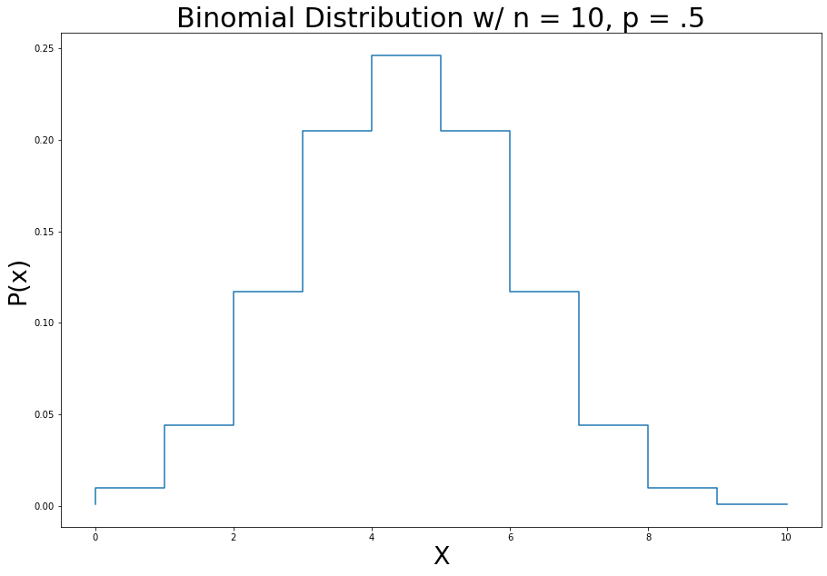

```python
# 2.1.B:
n = 10
p = 0.5
# defining list of r values
r_values = list(range(n + 1))
# list of pmf values
dist = [binom.pmf(r, n, p) for r in r_values]
# plotting the graph
plt.step(r_values, dist)
plt.xlabel('X', fontsize = 27)
plt.ylabel('P(x)', fontsize = 27)
plt.title('Binomial Distribution w/ n = 10, p = .5', fontsize = 30)
plt.show()
```

Above shows with n trials and the probablity of success being 50% what is the spread across those trials. You can see since it's a 50/50 shot, the spread is mirrored across the medium which is 5.

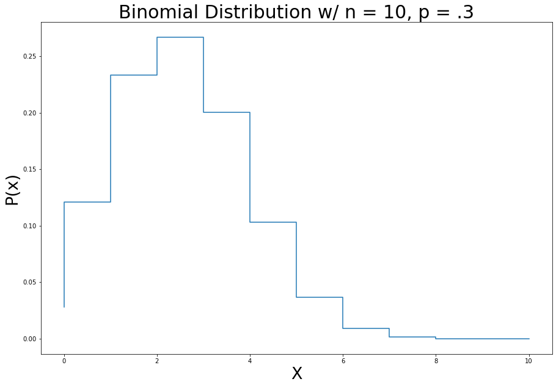

```python
n = 10
p = .3
# defining list of r values
r_values = list(range(n + 1))
# list of pmf values
dist = [binom.pmf(r, n, p) for r in r_values ]
# plotting the graph
plt.step(r_values, dist)
plt.xlabel('X', fontsize = 27)
plt.ylabel('P(x)', fontsize = 27)
plt.title('Binomial Distribution w/ n = 10, p = .3', fontsize = 30)
plt.show()
```

Above you see that with 10 trials and the probablity of success being 30%, what's the spread across the field. It seems like the mode of each trial is n*p.

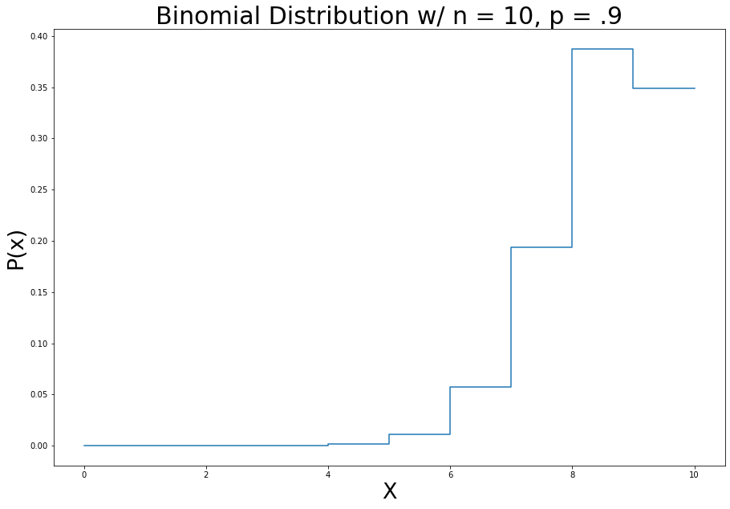

```python
n = 10
p = .9
# defining list of r values
r_values = list(range(n + 1))
# list of pmf values
dist = [binom.pmf(r, n, p) for r in r_values ]
# plotting the graph
plt.step(r_values, dist)
plt.xlabel('X', fontsize = 27)
plt.ylabel('P(x)', fontsize = 27)
plt.title('Binomial Distribution w/ n = 10, p = .9', fontsize = 30)
plt.show()
```

Seen in the code above with a binomial distrbution, it's almost impossible to succeed less than five times in a 10 trial grouping.

Problem 2.1.C: In a non-continuous binomial distrbution, what is the probablity that one will measure exactly 3 successful trials with 10 trials and the success rate being 50%?

```python
# 2.1.C
n = 10
p = .5
print("Probablity of measuring exactly 3 successful trials is " + str(stats.binom(n, p).cdf(3) - stats.binom(n,p).cdf(2)))
```

```
Probablity of measuring exactly 3 successful trials is 0.11718749999999993
```

In order to calculate the exact value I subtracted the CDF from zero to 3 from zero to 2 which would yield the probability of only 3 suceesses.

Problem 2.1.D: With a discrete distribution that means that we must have non-continuous trials with n. Therefore we cannot perform operations if the experiments aren't all complete/whole. An example being you cannot find the probability of 3 coin flips being heads out of 3.75 trials.

Problem 2.1.E: You can continuously change the probablity of success as that's defined between zero and one or zero and 100%. However, for trials and probable outcomes, they will have to be discrete. One can still have a mean that's continuous because that doesn't represent an actual state but rather an average value.